# ADHD management

## Intervention: int_atomoxetine

### Outcome: cognitive:continuous

No data #1.

## Intervention: int_atomoxetine

### Outcome: cognitive:categorical

Analyzing 0 studies.

No data.

## Intervention: int_atomoxetine

### Outcome: symptom:continuous

| ID | measure | mean_ctrl_cont | SD_ctrl_cont | n_ctrl_cont | mean_int_cont | SD_int_cont | n_int_cont | yi | se | study.design |
| --- | --- | --- | --- | --- | --- | --- | --- | --- | --- | --- |
| Kay, 2009{#2637} NS-NRI-ATX | ADHD-RS-IV (ADHD Rating Scale IV, Adult) | 18.400 | 7.200 | 15 | 27.800 | 6.900 | 14 | 1.2945790 | 0.4086449 | Crossover |
| Shim, 2022{#3242} NS-NRI-ATX | ASRS (Adult ADHD Self-Report Scale), change from baseline | 8.469 | 10.907 | 22 | 9.857 | 12.492 | 19 | -0.1166796 | 0.3134520 | RCT |
| Weisler, 2012{#1844} NS-NRI-ATX | ADHD-RS-IV (Attention-Deficit/Hyperactivity Disorder Rating Scale, Version IV) change from baseline | -15.700 | 13.390 | 68 | -15.300 | 14.520 | 73 | 0.0284439 | 0.1685449 | RCT |

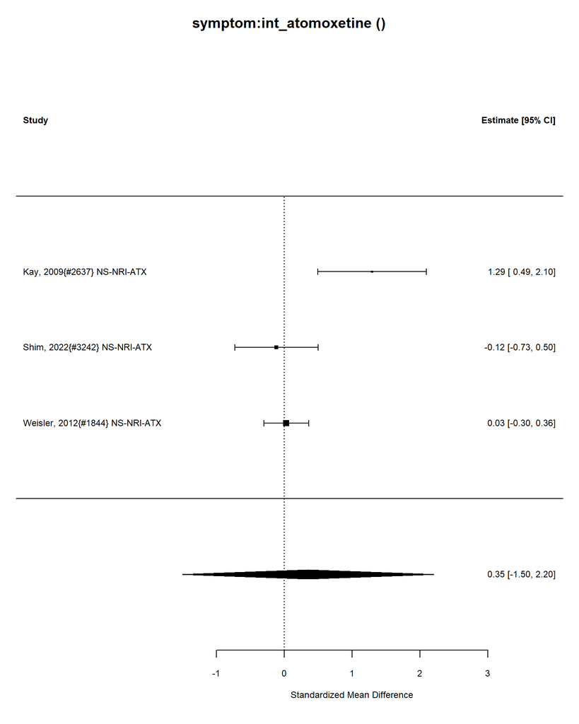

| estimate | conf.low | conf.high |
| --- | --- | --- |
| 0.35 | -1.5 | 2.2 |

Number of studies = 3

Intervention sample = 106

Control sample = 105

Total sample = 211.

I-squared = 84 %

Convert Effect Size to Real Units

Estimated effect in original units = 3.66.

##### Publication Bias Tests

###### Begg (non-parametric)

Rank Correlation Test for Funnel Plot Asymmetry Kendall’s tau = 1.0000, p = 0.3333

###### Egger (parametric)

Regression Test for Funnel Plot Asymmetry

Model: mixed-effects meta-regression model Predictor: standard error

Test for Funnel Plot Asymmetry: t = 1.0537, df = 1, p = 0.4834 Limit Estimate (as sei -> 0): b = -0.9240 (CI: -17.1864, 15.3384)

###### Trim and Fill

Estimate and Cis

|  | estimate | ci.lb | ci.ub |
| --- | --- | --- | --- |
| intrcpt | 0.35 | -1.5 | 2.2 |

### Meta-regression: stimulant vs non-stimulant

Not enough studies to compare stimulant and nonstimulant

### Meta-regression: AMPH vs MPH

### AMPH vs MPH meta-regression

Not enough studies to compare AMPH and MPH

## Meta-regression: Indirect comparison between combined vs(medication plus psychosocial) and medication

3 medication studies

0 combined studies

Not enough studies to compare medication and combined

## Meta-regression: Indirect comparison between combined vs(medication plus psychosocial) and psychosocial

0 psychosocial studies

0 combined studies

Not enough studies to compare psychosocial and combined

## Intervention: int_atomoxetine

### Outcome: symptom:categorical

Analyzing 1 studies.

Analyzing 1 studies.

### Control Types

| control | n |
| --- | --- |
| Placebo | 1 |

| ID | measure | yi | se | study.design |
| --- | --- | --- | --- | --- |
| Kay, 2009{#2637} NS-NRI-ATX | ADHD-RS score improvement from baseline (≥ 30% decrease from baseline) | 0.62 | 0.33 | Crossover |

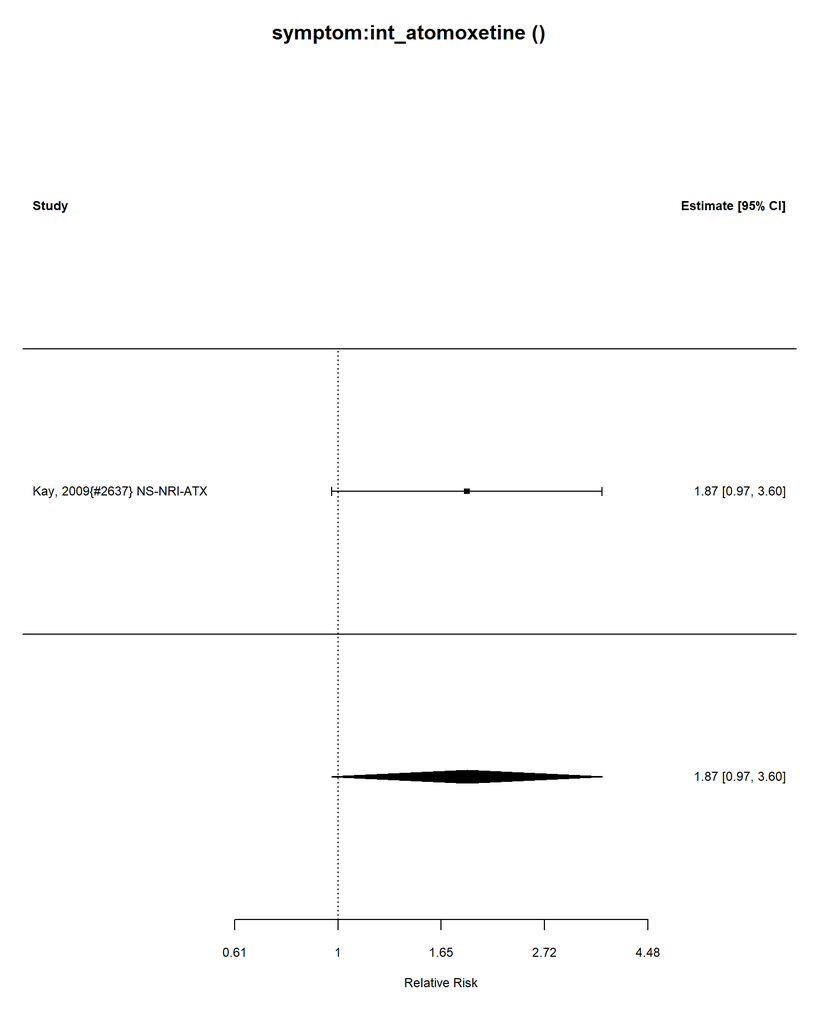

Number of studies = 1  
Intervention sample = 14  
Control sample = 14  
Total sample = 28

### Relative Risk Estimate

|  | estimate | se | zval | pval | ci.lb | ci.ub |
| --- | --- | --- | --- | --- | --- | --- |
| intrcpt | 1.858928 | 1.390968 | 6.488296 | 1.061837 | 0.9704455 | 3.59664 |

I-squared = 0 %

## Intervention: int_atomoxetine

### Outcome: substance_use:continuous

No data #1.

## Intervention: int_atomoxetine

### Outcome: substance_use:categorical

Analyzing 0 studies.

No data.

## Intervention: int_atomoxetine

### Outcome: relationship:continuous

No data #1.

## Intervention: int_atomoxetine

### Outcome: relationship:categorical

Analyzing 0 studies.

No data.

## Intervention: int_atomoxetine

### Outcome: BP:continuous

| ID | measure | mean_ctrl_cont | SD_ctrl_cont | n_ctrl_cont | mean_int_cont | SD_int_cont | n_int_cont | yi | se | study.design |
| --- | --- | --- | --- | --- | --- | --- | --- | --- | --- | --- |
| Kay, 2009{#2637} NS-NRI-ATX | Systolic blood pressure | 120.5 | 7.2 | 15 | 118.1 | 7.0 | 14 | -0.3283321 | 0.3741041 | Crossover |
| Shim, 2022{#3242} NS-NRI-ATX | Systolic blood pressure | 124.4 | 14.4 | 22 | 121.6 | 8.9 | 19 | -0.2255362 | 0.3141758 | RCT |

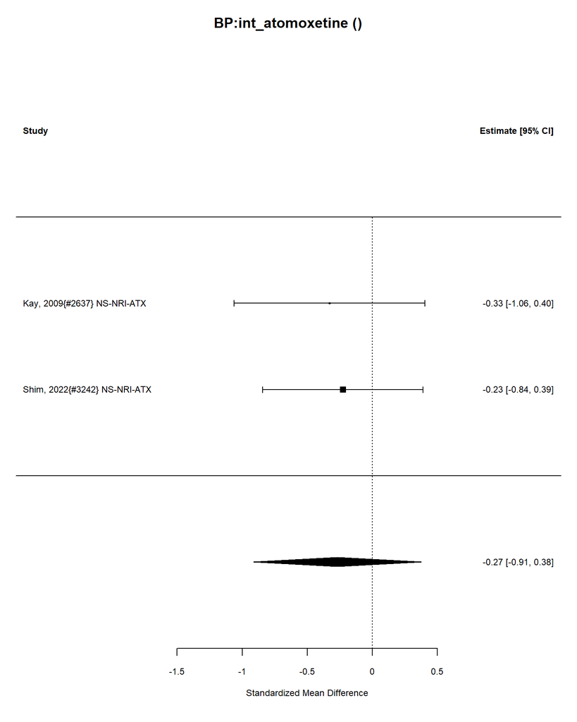

| estimate | conf.low | conf.high |
| --- | --- | --- |
| -0.27 | -0.91 | 0.38 |

Number of studies = 2

Intervention sample = 33

Control sample = 37

Total sample = 70.

I-squared = 0 %

Convert Effect Size to Real Units

Estimated effect in original units = -2.89.

## Intervention: int_atomoxetine

### Outcome: BP:categorical

Analyzing 0 studies.

No data.

## Intervention: int_atomoxetine

### Outcome: sleep_disturbance:continuous

No data #1.

## Intervention: int_atomoxetine

### Outcome: sleep_disturbance:categorical

Analyzing 1 studies.

Analyzing 1 studies.

### Control Types

| control | n |
| --- | --- |
| Placebo | 1 |

| ID | measure | yi | se | study.design |
| --- | --- | --- | --- | --- |
| Weisler, 2012{#1844} NS-NRI-ATX | Number of participants reporting insomnia | -1.47 | 1.11 | RCT |

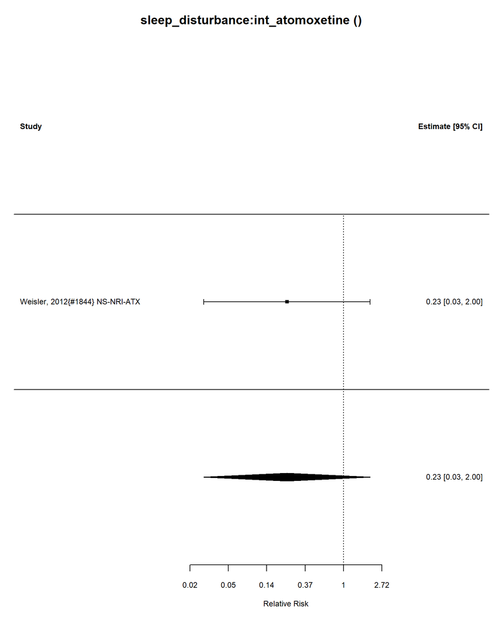

Number of studies = 1  
Intervention sample = 74  
Control sample = 73  
Total sample = 147

### Relative Risk Estimate

|  | estimate | se | zval | pval | ci.lb | ci.ub |
| --- | --- | --- | --- | --- | --- | --- |
| intrcpt | 0.2299255 | 3.034358 | 0.2644773 | 1.197217 | 0.0262523 | 2.013753 |

I-squared = 0 %

## Intervention: int_atomoxetine

### Outcome: AEs:continuous

No data #1.

## Intervention: int_atomoxetine

### Outcome: AEs:categorical

Analyzing 1 studies.

Analyzing 1 studies.

### Control Types

| control | n |
| --- | --- |
| Placebo | 1 |

| ID | measure | yi | se | study.design |
| --- | --- | --- | --- | --- |
| Weisler, 2012{#1844} NS-NRI-ATX | Number of participants reporting any adverse events | 0.02 | 0.08 | RCT |

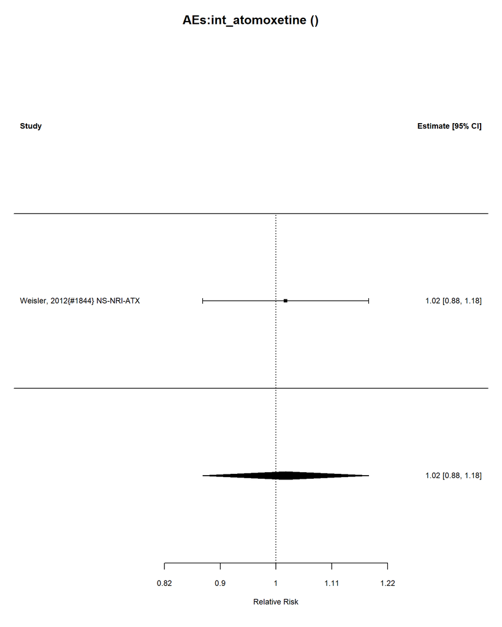

Number of studies = 1  
Intervention sample = 74  
Control sample = 73  
Total sample = 147

### Relative Risk Estimate

|  | estimate | se | zval | pval | ci.lb | ci.ub |
| --- | --- | --- | --- | --- | --- | --- |
| intrcpt | 1.020201 | 1.083287 | 1.2586 | 2.2705 | 0.8780954 | 1.185305 |

I-squared = 0 %

## Intervention: int_atomoxetine

### Outcome: mortality:continuous

No data #1.

## Intervention: int_atomoxetine

### Outcome: mortality:categorical

Analyzing 1 studies.

Analyzing 1 studies.

### Control Types

| control | n |
| --- | --- |
| Placebo | 1 |

| ID | measure | yi | se | study.design |
| --- | --- | --- | --- | --- |
| Weisler, 2012{#1844} NS-NRI-ATX | Number of deaths | 0.08 | 1.99 | RCT |

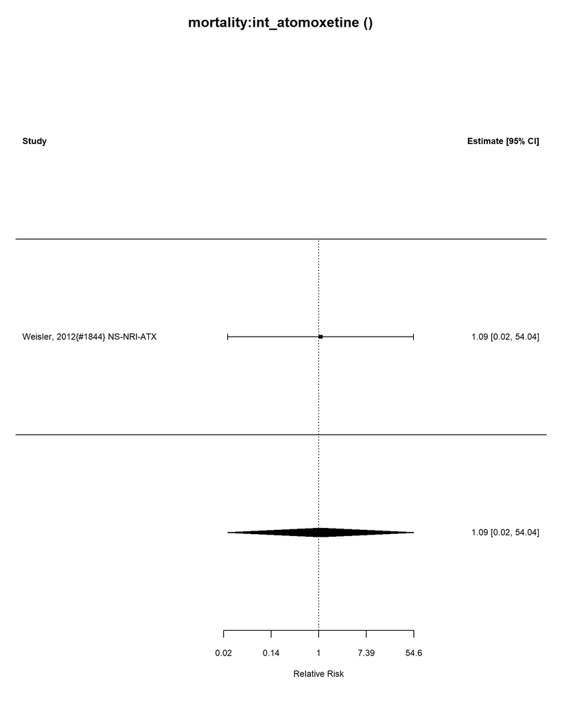

Number of studies = 1  
Intervention sample = 74  
Control sample = 73  
Total sample = 147

### Relative Risk Estimate

|  | estimate | se | zval | pval | ci.lb | ci.ub |
| --- | --- | --- | --- | --- | --- | --- |
| intrcpt | 1.083287 | 7.315534 | 1.040811 | 2.637945 | 0.0219278 | 54.05489 |

I-squared = 0 %

## Intervention: int_atomoxetine

### Outcome: behavior:continuous

No data #1.

## Intervention: int_atomoxetine

### Outcome: behavior:categorical

Analyzing 0 studies.

No data.

## Intervention: int_atomoxetine

### Outcome: appetite:continuous

No data #1.

## Intervention: int_atomoxetine

### Outcome: appetite:categorical

Analyzing 1 studies.

Analyzing 1 studies.

### Control Types

| control | n |
| --- | --- |
| Placebo | 1 |

| ID | measure | yi | se | study.design |
| --- | --- | --- | --- | --- |
| Weisler, 2012{#1844} NS-NRI-ATX | Decreased appetite adverse event | -0.8 | 0.42 | RCT |

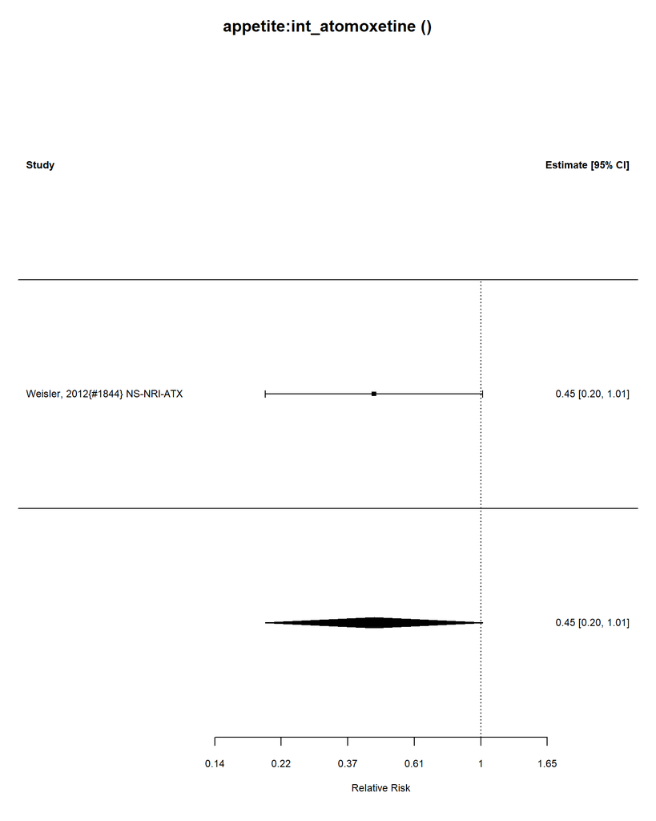

Number of studies = 1  
Intervention sample = 74  
Control sample = 73  
Total sample = 147

### Relative Risk Estimate

|  | estimate | se | zval | pval | ci.lb | ci.ub |
| --- | --- | --- | --- | --- | --- | --- |
| intrcpt | 0.449329 | 1.521962 | 0.1451482 | 1.051271 | 0.1978987 | 1.01005 |

I-squared = 0 %

## Intervention: int_atomoxetine

### Outcome: mood:continuous

No data #1.

## Intervention: int_atomoxetine

### Outcome: mood:categorical

Analyzing 1 studies.

Analyzing 1 studies.

### Control Types

| control | n |
| --- | --- |
| Placebo | 1 |

| ID | measure | yi | se | study.design |
| --- | --- | --- | --- | --- |
| Kay, 2009{#2637} NS-NRI-ATX | Irritability | 1.61 | 1.51 | Crossover |

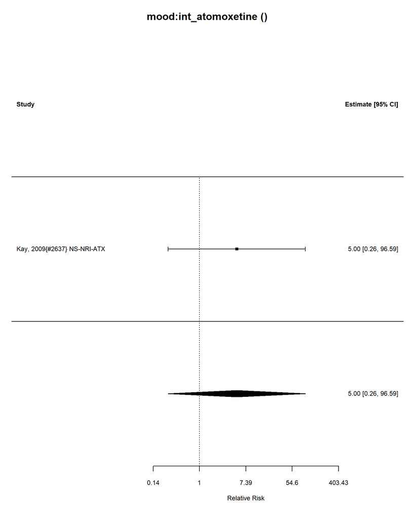

Number of studies = 1  
Intervention sample = 16  
Control sample = 16  
Total sample = 32

### Relative Risk Estimate

|  | estimate | se | zval | pval | ci.lb | ci.ub |
| --- | --- | --- | --- | --- | --- | --- |
| intrcpt | 5.002811 | 4.526731 | 2.915379 | 1.336428 | 0.2592403 | 96.54411 |

I-squared = 0 %

## MPH, AMPH, and NRI’s Section: Intervention: int_bupropion

## Intervention: int_bupropion

### Outcome: functional:continuous

No data #1.

## Intervention: int_bupropion

### Outcome: functional:categorical

Analyzing 0 studies.

No data.

## Intervention: int_bupropion

### Outcome: cognitive:continuous

No data #1.

## Intervention: int_bupropion

### Outcome: cognitive:categorical

Analyzing 0 studies.

No data.

## Intervention: int_bupropion

### Outcome: symptom:continuous

No data #1.

## Intervention: int_bupropion

### Outcome: symptom:categorical

Analyzing 0 studies.

No data.

## Intervention: int_bupropion

### Outcome: substance_use:continuous

No data #1.

## Intervention: int_bupropion

### Outcome: substance_use:categorical

Analyzing 0 studies.

No data.

## Intervention: int_bupropion

### Outcome: relationship:continuous

No data #1.

## Intervention: int_bupropion

### Outcome: relationship:categorical

Analyzing 0 studies.

No data.

## Intervention: int_bupropion

### Outcome: BP:continuous

No data #1.

## Intervention: int_bupropion

### Outcome: BP:categorical

Analyzing 0 studies.

No data.

## Intervention: int_bupropion

### Outcome: sleep_disturbance:continuous

No data #1.

## Intervention: int_bupropion

### Outcome: sleep_disturbance:categorical

Analyzing 0 studies.

No data.

## Intervention: int_bupropion

### Outcome: AEs:continuous

No data #1.

## Intervention: int_bupropion

### Outcome: AEs:categorical

Analyzing 0 studies.

No data.

## Intervention: int_bupropion

### Outcome: mortality:continuous

No data #1.

## Intervention: int_bupropion

### Outcome: mortality:categorical

Analyzing 0 studies.

No data.

## Intervention: int_bupropion

### Outcome: behavior:continuous

No data #1.

## Intervention: int_bupropion

### Outcome: behavior:categorical

Analyzing 0 studies.

No data.

## Intervention: int_bupropion

### Outcome: appetite:continuous

No data #1.

## Intervention: int_bupropion

### Outcome: appetite:categorical

Analyzing 0 studies.

No data.

## Intervention: int_bupropion

### Outcome: mood:continuous

No data #1.

## Intervention: int_bupropion

### Outcome: mood:categorical

Analyzing 0 studies.

No data.

## MPH, AMPH, and NRI’s Section: Intervention: int_CBT_only

## Intervention: int_CBT_only

### Outcome: functional:continuous

No data #1.

## Intervention: int_CBT_only

### Outcome: functional:categorical

Analyzing 0 studies.

No data.

## Intervention: int_CBT_only

### Outcome: cognitive:continuous

No data #1.

## Intervention: int_CBT_only

### Outcome: cognitive:categorical

Analyzing 0 studies.

No data.

## Intervention: int_CBT_only

### Outcome: symptom:continuous

No data #1.

## Intervention: int_CBT_only

### Outcome: symptom:categorical

Analyzing 0 studies.

No data.

## Intervention: int_CBT_only

### Outcome: substance_use:continuous

No data #1.

## Intervention: int_CBT_only

### Outcome: substance_use:categorical

Analyzing 0 studies.

No data.

## Intervention: int_CBT_only

### Outcome: relationship:continuous

No data #1.

## Intervention: int_CBT_only

### Outcome: relationship:categorical

Analyzing 0 studies.

No data.

## Intervention: int_CBT_only

### Outcome: BP:continuous

No data #1.

## Intervention: int_CBT_only

### Outcome: BP:categorical

Analyzing 0 studies.

No data.

## Intervention: int_CBT_only

### Outcome: sleep_disturbance:continuous

No data #1.

## Intervention: int_CBT_only

### Outcome: sleep_disturbance:categorical

Analyzing 0 studies.

No data.

## Intervention: int_CBT_only

### Outcome: AEs:continuous

No data #1.

## Intervention: int_CBT_only

### Outcome: AEs:categorical

Analyzing 0 studies.

No data.

## Intervention: int_CBT_only

### Outcome: mortality:continuous

No data #1.

## Intervention: int_CBT_only

### Outcome: mortality:categorical

Analyzing 0 studies.

No data.

## Intervention: int_CBT_only

### Outcome: behavior:continuous

No data #1.

## Intervention: int_CBT_only

### Outcome: behavior:categorical

Analyzing 0 studies.

No data.

## Intervention: int_CBT_only

### Outcome: appetite:continuous

No data #1.

## Intervention: int_CBT_only

### Outcome: appetite:categorical

Analyzing 0 studies.

No data.

## Intervention: int_CBT_only

### Outcome: mood:continuous

No data #1.

## Intervention: int_CBT_only

### Outcome: mood:categorical

Analyzing 0 studies.

No data.

## MPH, AMPH, and NRI’s Section: Intervention: int_DBT_only

## Intervention: int_DBT_only

### Outcome: functional:continuous

No data #1.

## Intervention: int_DBT_only

### Outcome: functional:categorical

Analyzing 0 studies.

No data.

## Intervention: int_DBT_only

### Outcome: cognitive:continuous

No data #1.

## Intervention: int_DBT_only

### Outcome: cognitive:categorical

Analyzing 0 studies.

No data.

## Intervention: int_DBT_only

### Outcome: symptom:continuous

No data #1.

## Intervention: int_DBT_only

### Outcome: symptom:categorical

Analyzing 0 studies.

No data.

## Intervention: int_DBT_only

### Outcome: substance_use:continuous

No data #1.

## Intervention: int_DBT_only

### Outcome: substance_use:categorical

Analyzing 0 studies.

No data.

## Intervention: int_DBT_only

### Outcome: relationship:continuous

No data #1.

## Intervention: int_DBT_only

### Outcome: relationship:categorical

Analyzing 0 studies.

No data.

## Intervention: int_DBT_only

### Outcome: BP:continuous

No data #1.

## Intervention: int_DBT_only

### Outcome: BP:categorical

Analyzing 0 studies.

No data.

## Intervention: int_DBT_only

### Outcome: sleep_disturbance:continuous

No data #1.

## Intervention: int_DBT_only

### Outcome: sleep_disturbance:categorical

Analyzing 0 studies.

No data.

## Intervention: int_DBT_only

### Outcome: AEs:continuous

No data #1.

## Intervention: int_DBT_only

### Outcome: AEs:categorical

Analyzing 0 studies.

No data.

## Intervention: int_DBT_only

### Outcome: mortality:continuous

No data #1.

## Intervention: int_DBT_only

### Outcome: mortality:categorical

Analyzing 0 studies.

No data.

## Intervention: int_DBT_only

### Outcome: behavior:continuous

No data #1.

## Intervention: int_DBT_only

### Outcome: behavior:categorical

Analyzing 0 studies.

No data.

## Intervention: int_DBT_only

### Outcome: appetite:continuous

No data #1.

## Intervention: int_DBT_only

### Outcome: appetite:categorical

Analyzing 0 studies.

No data.

## Intervention: int_DBT_only

### Outcome: mood:continuous

No data #1.

## Intervention: int_DBT_only

### Outcome: mood:categorical

Analyzing 0 studies.

No data.

## MPH, AMPH, and NRI’s Section: Intervention: int_MBCT_only

## Intervention: int_MBCT_only

### Outcome: functional:continuous

No data #1.

## Intervention: int_MBCT_only

### Outcome: functional:categorical

Analyzing 0 studies.

No data.

## Intervention: int_MBCT_only

### Outcome: cognitive:continuous

No data #1.

## Intervention: int_MBCT_only

### Outcome: cognitive:categorical

Analyzing 0 studies.

No data.

## Intervention: int_MBCT_only

### Outcome: symptom:continuous

No data #1.

## Intervention: int_MBCT_only

### Outcome: symptom:categorical

Analyzing 0 studies.

No data.

## Intervention: int_MBCT_only

### Outcome: substance_use:continuous

No data #1.

## Intervention: int_MBCT_only

### Outcome: substance_use:categorical

Analyzing 0 studies.

No data.

## Intervention: int_MBCT_only

### Outcome: relationship:continuous

No data #1.

## Intervention: int_MBCT_only

### Outcome: relationship:categorical

Analyzing 0 studies.

No data.

## Intervention: int_MBCT_only

### Outcome: BP:continuous

No data #1.

## Intervention: int_MBCT_only

### Outcome: BP:categorical

Analyzing 0 studies.

No data.

## Intervention: int_MBCT_only

### Outcome: sleep_disturbance:continuous

No data #1.

## Intervention: int_MBCT_only

### Outcome: sleep_disturbance:categorical

Analyzing 0 studies.

No data.

## Intervention: int_MBCT_only

### Outcome: AEs:continuous

No data #1.

## Intervention: int_MBCT_only

### Outcome: AEs:categorical

Analyzing 0 studies.

No data.

## Intervention: int_MBCT_only

### Outcome: mortality:continuous

No data #1.

## Intervention: int_MBCT_only

### Outcome: mortality:categorical

Analyzing 0 studies.

No data.

## Intervention: int_MBCT_only

### Outcome: behavior:continuous

No data #1.

## Intervention: int_MBCT_only

### Outcome: behavior:categorical

Analyzing 0 studies.

No data.

## Intervention: int_MBCT_only

### Outcome: appetite:continuous

No data #1.

## Intervention: int_MBCT_only

### Outcome: appetite:categorical

Analyzing 0 studies.

No data.

## Intervention: int_MBCT_only

### Outcome: mood:continuous

No data #1.

## Intervention: int_MBCT_only

### Outcome: mood:categorical

Analyzing 0 studies.

No data.

## MPH, AMPH, and NRI’s Section: Intervention: int_methylphenidate

## Intervention: int_methylphenidate

### Outcome: functional:continuous

No data #1.

## Intervention: int_methylphenidate

### Outcome: functional:categorical

Analyzing 0 studies.

No data.

## Intervention: int_methylphenidate

### Outcome: cognitive:continuous

No data #1.

## Intervention: int_methylphenidate

### Outcome: cognitive:categorical

Analyzing 0 studies.

No data.

## Intervention: int_methylphenidate

### Outcome: symptom:continuous

No data #1.

## Intervention: int_methylphenidate

### Outcome: symptom:categorical

Analyzing 0 studies.

No data.

## Intervention: int_methylphenidate

### Outcome: substance_use:continuous

No data #1.

## Intervention: int_methylphenidate

### Outcome: substance_use:categorical

Analyzing 0 studies.

No data.

## Intervention: int_methylphenidate

### Outcome: relationship:continuous

No data #1.

## Intervention: int_methylphenidate

### Outcome: relationship:categorical

Analyzing 0 studies.

No data.

## Intervention: int_methylphenidate

### Outcome: BP:continuous

No data #1.

## Intervention: int_methylphenidate

### Outcome: BP:categorical

Analyzing 0 studies.

No data.

## Intervention: int_methylphenidate

### Outcome: sleep_disturbance:continuous

No data #1.

## Intervention: int_methylphenidate

### Outcome: sleep_disturbance:categorical

Analyzing 0 studies.

No data.

## Intervention: int_methylphenidate

### Outcome: AEs:continuous

No data #1.

## Intervention: int_methylphenidate

### Outcome: AEs:categorical

Analyzing 0 studies.

No data.

## Intervention: int_methylphenidate

### Outcome: mortality:continuous

No data #1.

## Intervention: int_methylphenidate

### Outcome: mortality:categorical

Analyzing 0 studies.

No data.

## Intervention: int_methylphenidate

### Outcome: behavior:continuous

No data #1.

## Intervention: int_methylphenidate

### Outcome: behavior:categorical

Analyzing 0 studies.

No data.

## Intervention: int_methylphenidate

### Outcome: appetite:continuous

No data #1.

## Intervention: int_methylphenidate

### Outcome: appetite:categorical

Analyzing 0 studies.

No data.

## Intervention: int_methylphenidate

### Outcome: mood:continuous

No data #1.

## Intervention: int_methylphenidate

### Outcome: mood:categorical

Analyzing 0 studies.

No data.

## MPH, AMPH, and NRI’s Section: Intervention: int_mindfulness

## Intervention: int_mindfulness

### Outcome: functional:continuous

No data #1.

## Intervention: int_mindfulness

### Outcome: functional:categorical

Analyzing 0 studies.

No data.

## Intervention: int_mindfulness

### Outcome: cognitive:continuous

No data #1.

## Intervention: int_mindfulness

### Outcome: cognitive:categorical

Analyzing 0 studies.

No data.

## Intervention: int_mindfulness

### Outcome: symptom:continuous

No data #1.

## Intervention: int_mindfulness

### Outcome: symptom:categorical

Analyzing 0 studies.

No data.

## Intervention: int_mindfulness

### Outcome: substance_use:continuous

No data #1.

## Intervention: int_mindfulness

### Outcome: substance_use:categorical

Analyzing 0 studies.

No data.

## Intervention: int_mindfulness

### Outcome: relationship:continuous

No data #1.

## Intervention: int_mindfulness

### Outcome: relationship:categorical

Analyzing 0 studies.

No data.

## Intervention: int_mindfulness

### Outcome: BP:continuous

No data #1.

## Intervention: int_mindfulness

### Outcome: BP:categorical

Analyzing 0 studies.

No data.

## Intervention: int_mindfulness

### Outcome: sleep_disturbance:continuous

No data #1.

## Intervention: int_mindfulness

### Outcome: sleep_disturbance:categorical

Analyzing 0 studies.

No data.

## Intervention: int_mindfulness

### Outcome: AEs:continuous

No data #1.

## Intervention: int_mindfulness

### Outcome: AEs:categorical

Analyzing 0 studies.

No data.

## Intervention: int_mindfulness

### Outcome: mortality:continuous

No data #1.

## Intervention: int_mindfulness

### Outcome: mortality:categorical

Analyzing 0 studies.

No data.

## Intervention: int_mindfulness

### Outcome: behavior:continuous

No data #1.

## Intervention: int_mindfulness

### Outcome: behavior:categorical

Analyzing 0 studies.

No data.

## Intervention: int_mindfulness

### Outcome: appetite:continuous

No data #1.

## Intervention: int_mindfulness

### Outcome: appetite:categorical

Analyzing 0 studies.

No data.

## Intervention: int_mindfulness

### Outcome: mood:continuous

No data #1.

## Intervention: int_mindfulness

### Outcome: mood:categorical

Analyzing 0 studies.

No data.

## MPH, AMPH, and NRI’s Section: Intervention: int_nonstimulant

## Intervention: int_nonstimulant

### Outcome: functional:continuous

| ID | measure | mean_ctrl_cont | SD_ctrl_cont | n_ctrl_cont | mean_int_cont | SD_int_cont | n_int_cont | yi | se | study.design |
| --- | --- | --- | --- | --- | --- | --- | --- | --- | --- | --- |
| Shim, 2022{#3242} NS-NRI-ATX | SDS (Sheehan Disability Scale) | 3.906 | 6.827 | 22 | 4.464 | 7.623 | 19 | -0.0759423 | 0.3132993 | RCT |

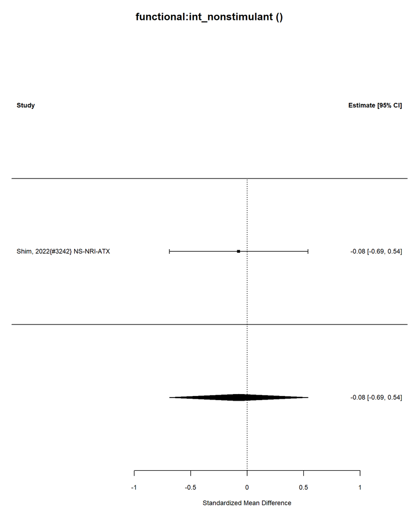

| estimate | conf.low | conf.high |
| --- | --- | --- |
| -0.08 | -0.69 | 0.54 |

Number of studies = 1

Intervention sample = 19

Control sample = 22

Total sample = 41.

I-squared = 0 %

Convert Effect Size to Real Units

Estimated effect in original units = -0.52.

## Intervention: int_nonstimulant

### Outcome: functional:categorical

Analyzing 0 studies.

No data.

## Intervention: int_nonstimulant

### Outcome: cognitive:continuous

No data #1.

## Intervention: int_nonstimulant

### Outcome: cognitive:categorical

Analyzing 0 studies.

No data.

## Intervention: int_nonstimulant

### Outcome: symptom:continuous

| ID | measure | mean_ctrl_cont | SD_ctrl_cont | n_ctrl_cont | mean_int_cont | SD_int_cont | n_int_cont | yi | se | study.design |
| --- | --- | --- | --- | --- | --- | --- | --- | --- | --- | --- |
| Kay, 2009{#2637} NS-NRI-ATX | ADHD-RS-IV (ADHD Rating Scale IV, Adult) | 18.400 | 7.200 | 15 | 27.800 | 6.900 | 14 | 1.2945790 | 0.4086449 | Crossover |
| Shim, 2022{#3242} NS-NRI-ATX | ASRS (Adult ADHD Self-Report Scale), change from baseline | 8.469 | 10.907 | 22 | 9.857 | 12.492 | 19 | -0.1166796 | 0.3134520 | RCT |
| Weisler, 2012{#1844} NS-NRI-ATX | ADHD-RS-IV (Attention-Deficit/Hyperactivity Disorder Rating Scale, Version IV) change from baseline | -15.700 | 13.390 | 68 | -15.300 | 14.520 | 73 | 0.0284439 | 0.1685449 | RCT |

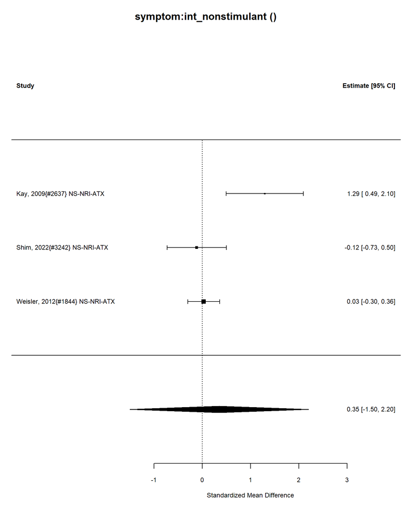

| estimate | conf.low | conf.high |
| --- | --- | --- |
| 0.35 | -1.5 | 2.2 |

Number of studies = 3

Intervention sample = 106

Control sample = 105

Total sample = 211.

I-squared = 84 %

Convert Effect Size to Real Units

Estimated effect in original units = 3.66.

##### Publication Bias Tests

###### Begg (non-parametric)

Rank Correlation Test for Funnel Plot Asymmetry Kendall’s tau = 1.0000, p = 0.3333

###### Egger (parametric)

Regression Test for Funnel Plot Asymmetry

Model: mixed-effects meta-regression model Predictor: standard error

Test for Funnel Plot Asymmetry: t = 1.0537, df = 1, p = 0.4834 Limit Estimate (as sei -> 0): b = -0.9240 (CI: -17.1864, 15.3384)

###### Trim and Fill

Estimate and Cis

|  | estimate | ci.lb | ci.ub |
| --- | --- | --- | --- |
| intrcpt | 0.35 | -1.5 | 2.2 |

### Meta-regression: stimulant vs non-stimulant

Not enough studies to compare stimulant and nonstimulant

### Meta-regression: AMPH vs MPH

### AMPH vs MPH meta-regression

Not enough studies to compare AMPH and MPH

## Meta-regression: Indirect comparison between combined vs(medication plus psychosocial) and medication

3 medication studies

0 combined studies

Not enough studies to compare medication and combined

## Meta-regression: Indirect comparison between combined vs(medication plus psychosocial) and psychosocial

0 psychosocial studies

0 combined studies

Not enough studies to compare psychosocial and combined

## Intervention: int_nonstimulant

### Outcome: symptom:categorical

Analyzing 1 studies.

Analyzing 1 studies.

### Control Types

| control | n |
| --- | --- |
| Placebo | 1 |

| ID | measure | yi | se | study.design |
| --- | --- | --- | --- | --- |
| Kay, 2009{#2637} NS-NRI-ATX | ADHD-RS score improvement from baseline (≥ 30% decrease from baseline) | 0.62 | 0.33 | Crossover |

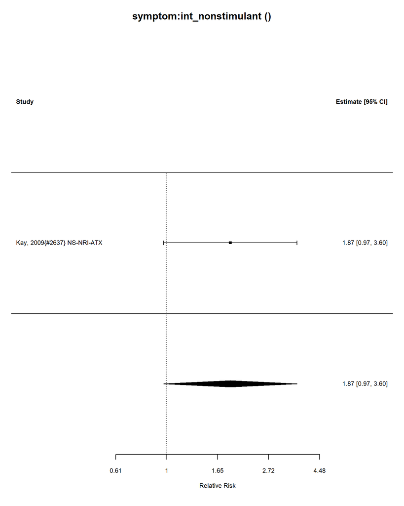

Number of studies = 1  
Intervention sample = 14  
Control sample = 14  
Total sample = 28

### Relative Risk Estimate

|  | estimate | se | zval | pval | ci.lb | ci.ub |
| --- | --- | --- | --- | --- | --- | --- |
| intrcpt | 1.858928 | 1.390968 | 6.488296 | 1.061837 | 0.9704455 | 3.59664 |

I-squared = 0 %

## Intervention: int_nonstimulant

### Outcome: substance_use:continuous

No data #1.

## Intervention: int_nonstimulant

### Outcome: substance_use:categorical

Analyzing 0 studies.

No data.

## Intervention: int_nonstimulant

### Outcome: relationship:continuous

No data #1.

## Intervention: int_nonstimulant

### Outcome: relationship:categorical

Analyzing 0 studies.

No data.

## Intervention: int_nonstimulant

### Outcome: BP:continuous

| ID | measure | mean_ctrl_cont | SD_ctrl_cont | n_ctrl_cont | mean_int_cont | SD_int_cont | n_int_cont | yi | se | study.design |
| --- | --- | --- | --- | --- | --- | --- | --- | --- | --- | --- |
| Kay, 2009{#2637} NS-NRI-ATX | Systolic blood pressure | 120.5 | 7.2 | 15 | 118.1 | 7.0 | 14 | -0.3283321 | 0.3741041 | Crossover |
| Shim, 2022{#3242} NS-NRI-ATX | Systolic blood pressure | 124.4 | 14.4 | 22 | 121.6 | 8.9 | 19 | -0.2255362 | 0.3141758 | RCT |

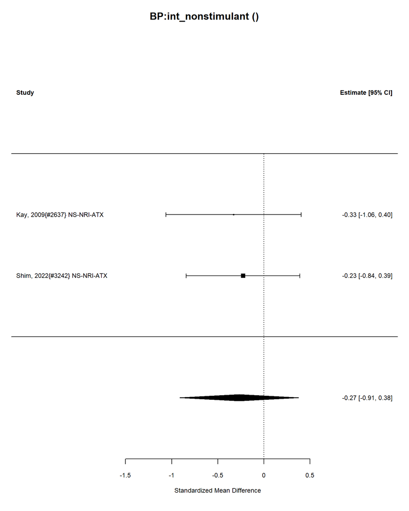

| estimate | conf.low | conf.high |
| --- | --- | --- |
| -0.27 | -0.91 | 0.38 |

Number of studies = 2

Intervention sample = 33

Control sample = 37

Total sample = 70.

I-squared = 0 %

Convert Effect Size to Real Units

Estimated effect in original units = -2.89.

## Intervention: int_nonstimulant

### Outcome: BP:categorical

Analyzing 0 studies.

No data.

## Intervention: int_nonstimulant

### Outcome: sleep_disturbance:continuous

No data #1.

## Intervention: int_nonstimulant

### Outcome: sleep_disturbance:categorical

Analyzing 1 studies.

Analyzing 1 studies.

### Control Types

| control | n |
| --- | --- |
| Placebo | 1 |

| ID | measure | yi | se | study.design |
| --- | --- | --- | --- | --- |
| Weisler, 2012{#1844} NS-NRI-ATX | Number of participants reporting insomnia | -1.47 | 1.11 | RCT |

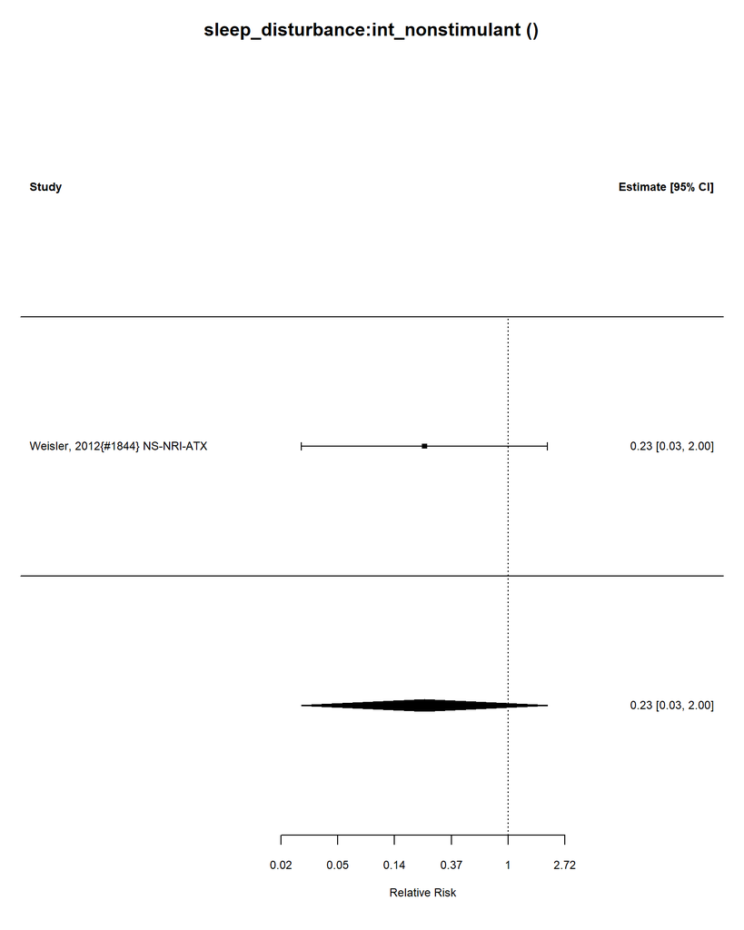

Number of studies = 1  
Intervention sample = 74  
Control sample = 73  
Total sample = 147

### Relative Risk Estimate

|  | estimate | se | zval | pval | ci.lb | ci.ub |
| --- | --- | --- | --- | --- | --- | --- |
| intrcpt | 0.2299255 | 3.034358 | 0.2644773 | 1.197217 | 0.0262523 | 2.013753 |

I-squared = 0 %

## Intervention: int_nonstimulant

### Outcome: AEs:continuous

No data #1.

## Intervention: int_nonstimulant

### Outcome: AEs:categorical

Analyzing 1 studies.

Analyzing 1 studies.

### Control Types

| control | n |
| --- | --- |
| Placebo | 1 |

| ID | measure | yi | se | study.design |
| --- | --- | --- | --- | --- |
| Weisler, 2012{#1844} NS-NRI-ATX | Number of participants reporting any adverse events | 0.02 | 0.08 | RCT |

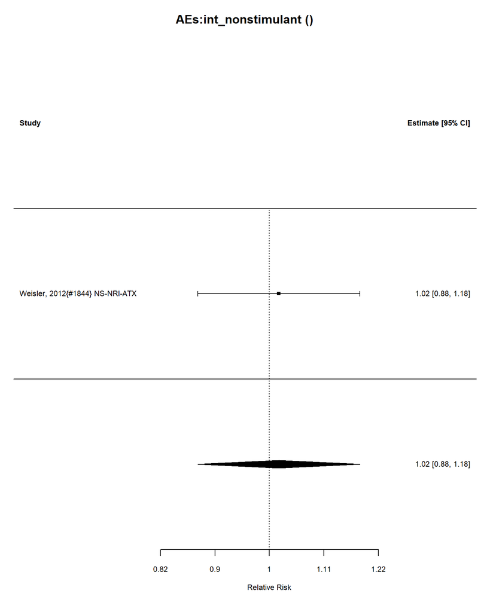

Number of studies = 1  
Intervention sample = 74  
Control sample = 73  
Total sample = 147

### Relative Risk Estimate

|  | estimate | se | zval | pval | ci.lb | ci.ub |
| --- | --- | --- | --- | --- | --- | --- |
| intrcpt | 1.020201 | 1.083287 | 1.2586 | 2.2705 | 0.8780954 | 1.185305 |

I-squared = 0 %

## Intervention: int_nonstimulant

### Outcome: mortality:continuous

No data #1.

## Intervention: int_nonstimulant

### Outcome: mortality:categorical

Analyzing 1 studies.

Analyzing 1 studies.

### Control Types

| control | n |
| --- | --- |
| Placebo | 1 |

| ID | measure | yi | se | study.design |
| --- | --- | --- | --- | --- |
| Weisler, 2012{#1844} NS-NRI-ATX | Number of deaths | 0.08 | 1.99 | RCT |

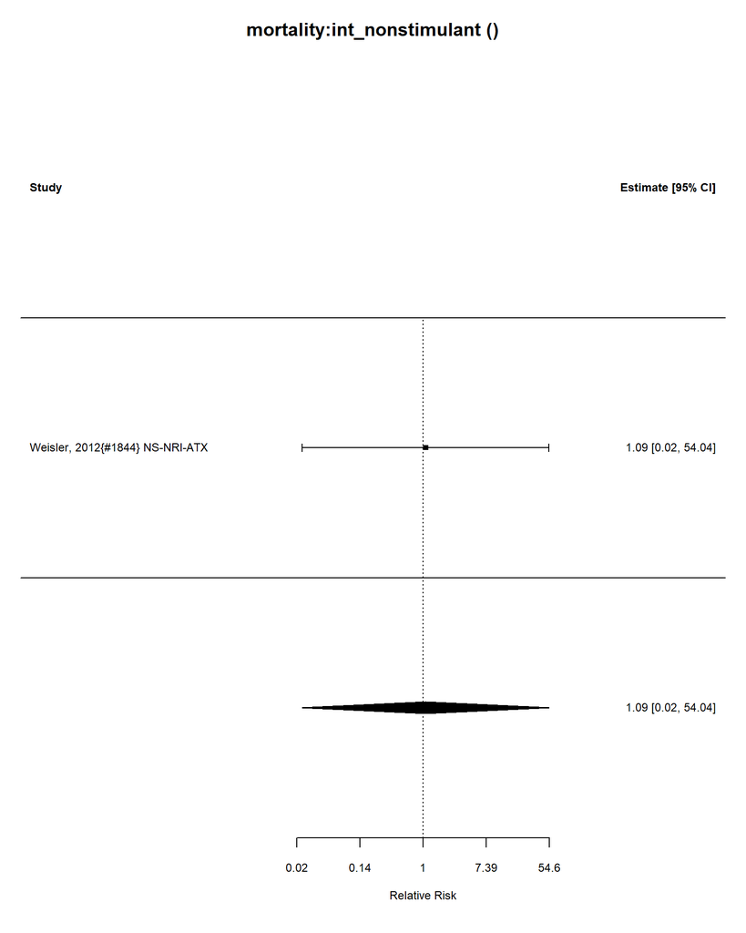

Number of studies = 1  
Intervention sample = 74  
Control sample = 73  
Total sample = 147

### Relative Risk Estimate

|  | estimate | se | zval | pval | ci.lb | ci.ub |
| --- | --- | --- | --- | --- | --- | --- |
| intrcpt | 1.083287 | 7.315534 | 1.040811 | 2.637945 | 0.0219278 | 54.05489 |

I-squared = 0 %

## Intervention: int_nonstimulant

### Outcome: behavior:continuous

No data #1.

## Intervention: int_nonstimulant

### Outcome: behavior:categorical

Analyzing 0 studies.

No data.

## Intervention: int_nonstimulant

### Outcome: appetite:continuous

No data #1.

## Intervention: int_nonstimulant

### Outcome: appetite:categorical

Analyzing 1 studies.

Analyzing 1 studies.

### Control Types

| control | n |
| --- | --- |
| Placebo | 1 |

| ID | measure | yi | se | study.design |
| --- | --- | --- | --- | --- |
| Weisler, 2012{#1844} NS-NRI-ATX | Decreased appetite adverse event | -0.8 | 0.42 | RCT |

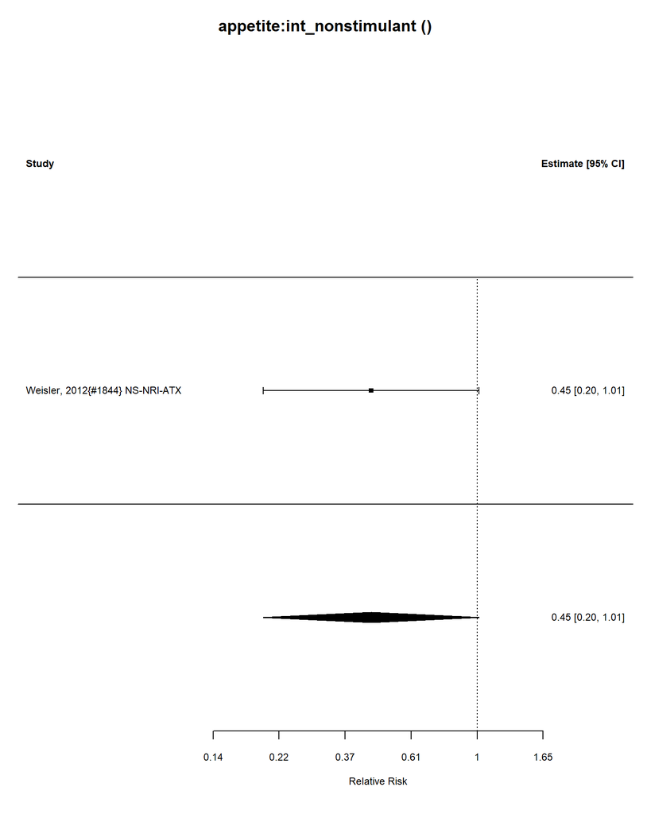

Number of studies = 1  
Intervention sample = 74  
Control sample = 73  
Total sample = 147

### Relative Risk Estimate

|  | estimate | se | zval | pval | ci.lb | ci.ub |
| --- | --- | --- | --- | --- | --- | --- |
| intrcpt | 0.449329 | 1.521962 | 0.1451482 | 1.051271 | 0.1978987 | 1.01005 |

I-squared = 0 %

## Intervention: int_nonstimulant

### Outcome: mood:continuous

No data #1.

## Intervention: int_nonstimulant

### Outcome: mood:categorical

Analyzing 1 studies.

Analyzing 1 studies.

### Control Types

| control | n |
| --- | --- |
| Placebo | 1 |

| ID | measure | yi | se | study.design |
| --- | --- | --- | --- | --- |
| Kay, 2009{#2637} NS-NRI-ATX | Irritability | 1.61 | 1.51 | Crossover |

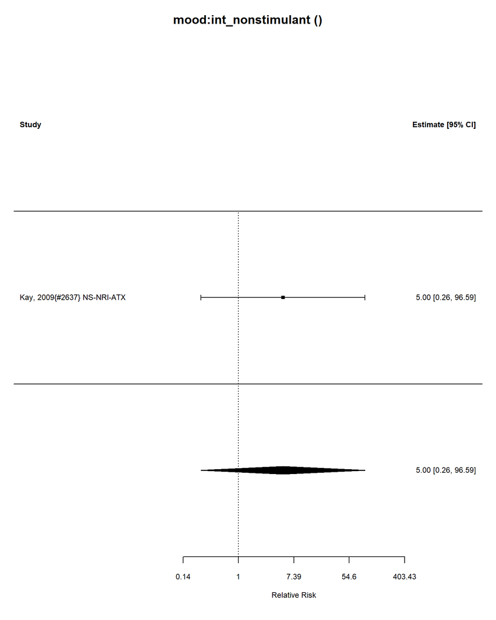

Number of studies = 1  
Intervention sample = 16  
Control sample = 16  
Total sample = 32

### Relative Risk Estimate

|  | estimate | se | zval | pval | ci.lb | ci.ub |
| --- | --- | --- | --- | --- | --- | --- |
| intrcpt | 5.002811 | 4.526731 | 2.915379 | 1.336428 | 0.2592403 | 96.54411 |

I-squared = 0 %

## MPH, AMPH, and NRI’s Section: Intervention: int_NRI

## Intervention: int_NRI

### Outcome: functional:continuous

| ID | measure | mean_ctrl_cont | SD_ctrl_cont | n_ctrl_cont | mean_int_cont | SD_int_cont | n_int_cont | yi | se | study.design |
| --- | --- | --- | --- | --- | --- | --- | --- | --- | --- | --- |
| Shim, 2022{#3242} NS-NRI-ATX | SDS (Sheehan Disability Scale) | 3.906 | 6.827 | 22 | 4.464 | 7.623 | 19 | -0.0759423 | 0.3132993 | RCT |

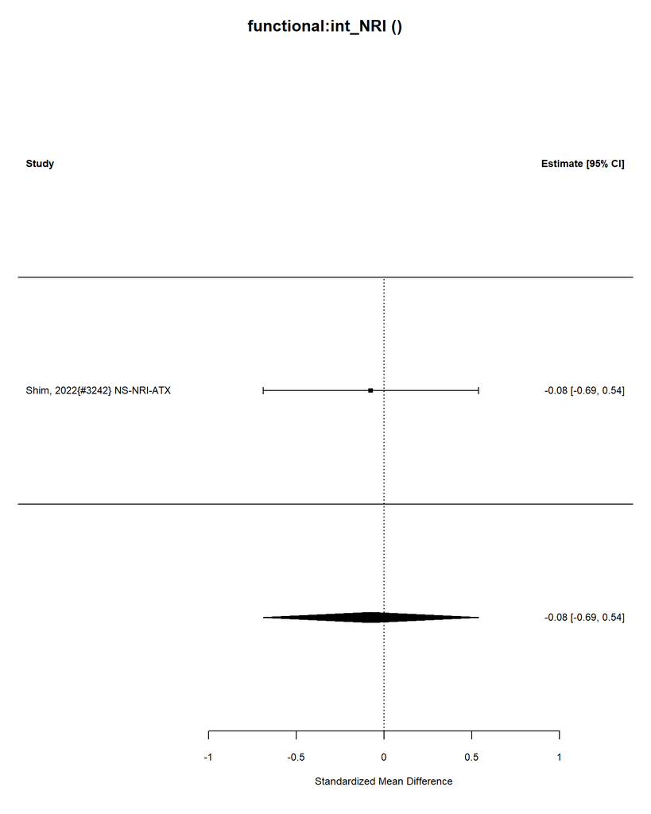

| estimate | conf.low | conf.high |
| --- | --- | --- |
| -0.08 | -0.69 | 0.54 |

Number of studies = 1

Intervention sample = 19

Control sample = 22

Total sample = 41.

I-squared = 0 %

Convert Effect Size to Real Units

Estimated effect in original units = -0.52.

## Intervention: int_NRI

### Outcome: functional:categorical

Analyzing 0 studies.

No data.

## Intervention: int_NRI

### Outcome: cognitive:continuous

No data #1.

## Intervention: int_NRI

### Outcome: cognitive:categorical

Analyzing 0 studies.

No data.

## Intervention: int_NRI

### Outcome: symptom:continuous

| ID | measure | mean_ctrl_cont | SD_ctrl_cont | n_ctrl_cont | mean_int_cont | SD_int_cont | n_int_cont | yi | se | study.design |
| --- | --- | --- | --- | --- | --- | --- | --- | --- | --- | --- |
| Kay, 2009{#2637} NS-NRI-ATX | ADHD-RS-IV (ADHD Rating Scale IV, Adult) | 18.400 | 7.200 | 15 | 27.800 | 6.900 | 14 | 1.2945790 | 0.4086449 | Crossover |
| Shim, 2022{#3242} NS-NRI-ATX | ASRS (Adult ADHD Self-Report Scale), change from baseline | 8.469 | 10.907 | 22 | 9.857 | 12.492 | 19 | -0.1166796 | 0.3134520 | RCT |
| Weisler, 2012{#1844} NS-NRI-ATX | ADHD-RS-IV (Attention-Deficit/Hyperactivity Disorder Rating Scale, Version IV) change from baseline | -15.700 | 13.390 | 68 | -15.300 | 14.520 | 73 | 0.0284439 | 0.1685449 | RCT |

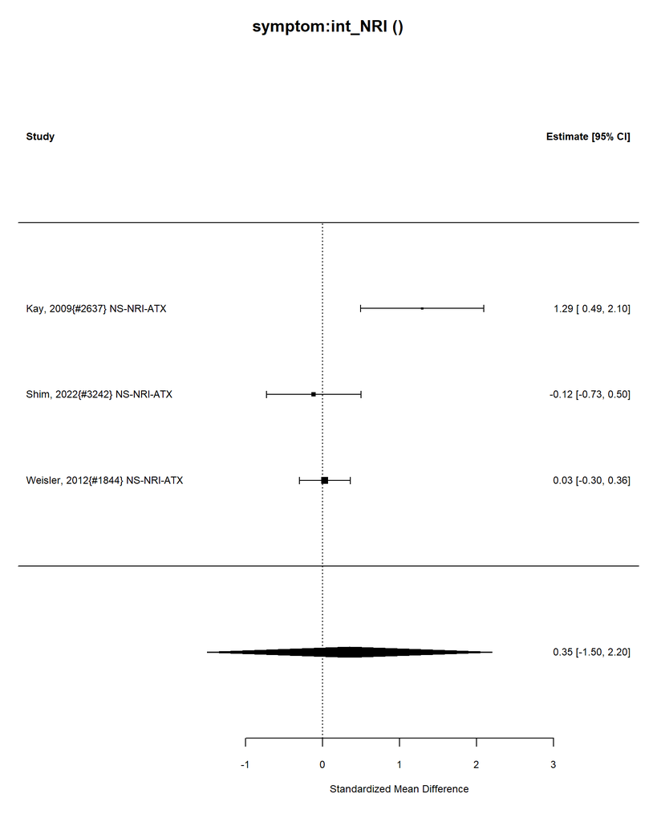

| estimate | conf.low | conf.high |
| --- | --- | --- |
| 0.35 | -1.5 | 2.2 |

Number of studies = 3

Intervention sample = 106

Control sample = 105

Total sample = 211.

I-squared = 84 %

Convert Effect Size to Real Units

Estimated effect in original units = 3.66.

##### Publication Bias Tests

###### Begg (non-parametric)

Rank Correlation Test for Funnel Plot Asymmetry Kendall’s tau = 1.0000, p = 0.3333

###### Egger (parametric)

Regression Test for Funnel Plot Asymmetry

Model: mixed-effects meta-regression model Predictor: standard error

Test for Funnel Plot Asymmetry: t = 1.0537, df = 1, p = 0.4834 Limit Estimate (as sei -> 0): b = -0.9240 (CI: -17.1864, 15.3384)

###### Trim and Fill

Estimate and Cis

|  | estimate | ci.lb | ci.ub |
| --- | --- | --- | --- |
| intrcpt | 0.35 | -1.5 | 2.2 |

### Meta-regression: stimulant vs non-stimulant

Not enough studies to compare stimulant and nonstimulant

### Meta-regression: AMPH vs MPH

### AMPH vs MPH meta-regression

Not enough studies to compare AMPH and MPH

## Meta-regression: Indirect comparison between combined vs(medication plus psychosocial) and medication

3 medication studies

0 combined studies

Not enough studies to compare medication and combined

## Meta-regression: Indirect comparison between combined vs(medication plus psychosocial) and psychosocial

0 psychosocial studies

0 combined studies

Not enough studies to compare psychosocial and combined

## Intervention: int_NRI

### Outcome: symptom:categorical

Analyzing 1 studies.

Analyzing 1 studies.

### Control Types

| control | n |
| --- | --- |
| Placebo | 1 |

| ID | measure | yi | se | study.design |
| --- | --- | --- | --- | --- |
| Kay, 2009{#2637} NS-NRI-ATX | ADHD-RS score improvement from baseline (≥ 30% decrease from baseline) | 0.62 | 0.33 | Crossover |

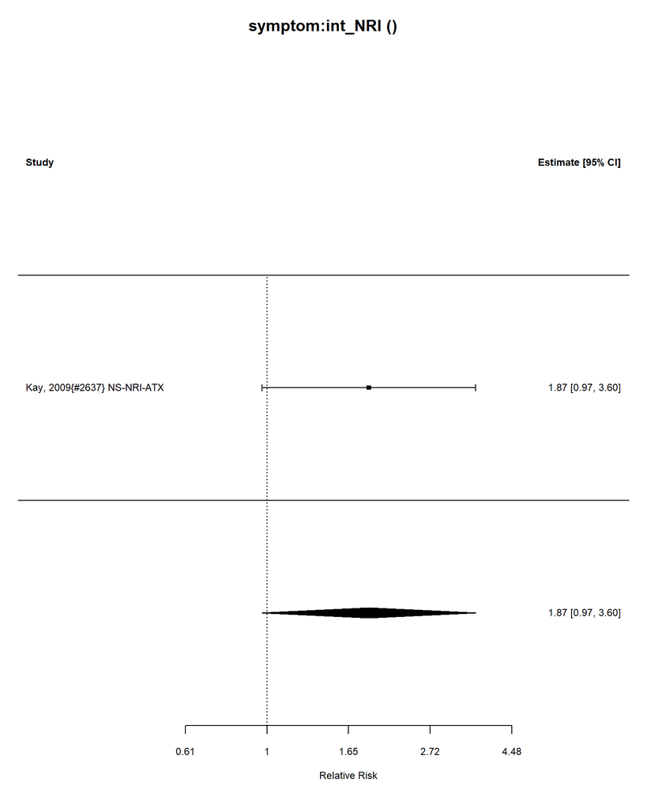

Number of studies = 1  
Intervention sample = 14  
Control sample = 14  
Total sample = 28

### Relative Risk Estimate

|  | estimate | se | zval | pval | ci.lb | ci.ub |
| --- | --- | --- | --- | --- | --- | --- |
| intrcpt | 1.858928 | 1.390968 | 6.488296 | 1.061837 | 0.9704455 | 3.59664 |

I-squared = 0 %

## Intervention: int_NRI

### Outcome: substance_use:continuous

No data #1.

## Intervention: int_NRI

### Outcome: substance_use:categorical

Analyzing 0 studies.

No data.

## Intervention: int_NRI

### Outcome: relationship:continuous

No data #1.

## Intervention: int_NRI

### Outcome: relationship:categorical

Analyzing 0 studies.

No data.

## Intervention: int_NRI

### Outcome: BP:continuous

| ID | measure | mean_ctrl_cont | SD_ctrl_cont | n_ctrl_cont | mean_int_cont | SD_int_cont | n_int_cont | yi | se | study.design |
| --- | --- | --- | --- | --- | --- | --- | --- | --- | --- | --- |
| Kay, 2009{#2637} NS-NRI-ATX | Systolic blood pressure | 120.5 | 7.2 | 15 | 118.1 | 7.0 | 14 | -0.3283321 | 0.3741041 | Crossover |
| Shim, 2022{#3242} NS-NRI-ATX | Systolic blood pressure | 124.4 | 14.4 | 22 | 121.6 | 8.9 | 19 | -0.2255362 | 0.3141758 | RCT |

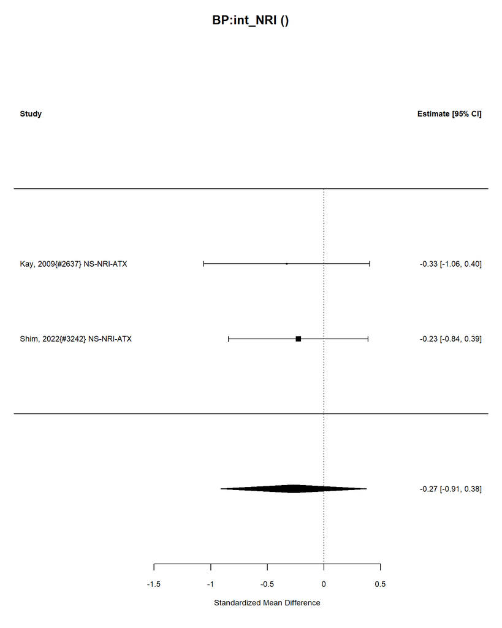

| estimate | conf.low | conf.high |
| --- | --- | --- |
| -0.27 | -0.91 | 0.38 |

Number of studies = 2

Intervention sample = 33

Control sample = 37

Total sample = 70.

I-squared = 0 %

Convert Effect Size to Real Units

Estimated effect in original units = -2.89.

## Intervention: int_NRI

### Outcome: BP:categorical

Analyzing 0 studies.

No data.

## Intervention: int_NRI

### Outcome: sleep_disturbance:continuous

No data #1.

## Intervention: int_NRI

### Outcome: sleep_disturbance:categorical

Analyzing 1 studies.

Analyzing 1 studies.

### Control Types

| control | n |
| --- | --- |
| Placebo | 1 |

| ID | measure | yi | se | study.design |
| --- | --- | --- | --- | --- |
| Weisler, 2012{#1844} NS-NRI-ATX | Number of participants reporting insomnia | -1.47 | 1.11 | RCT |

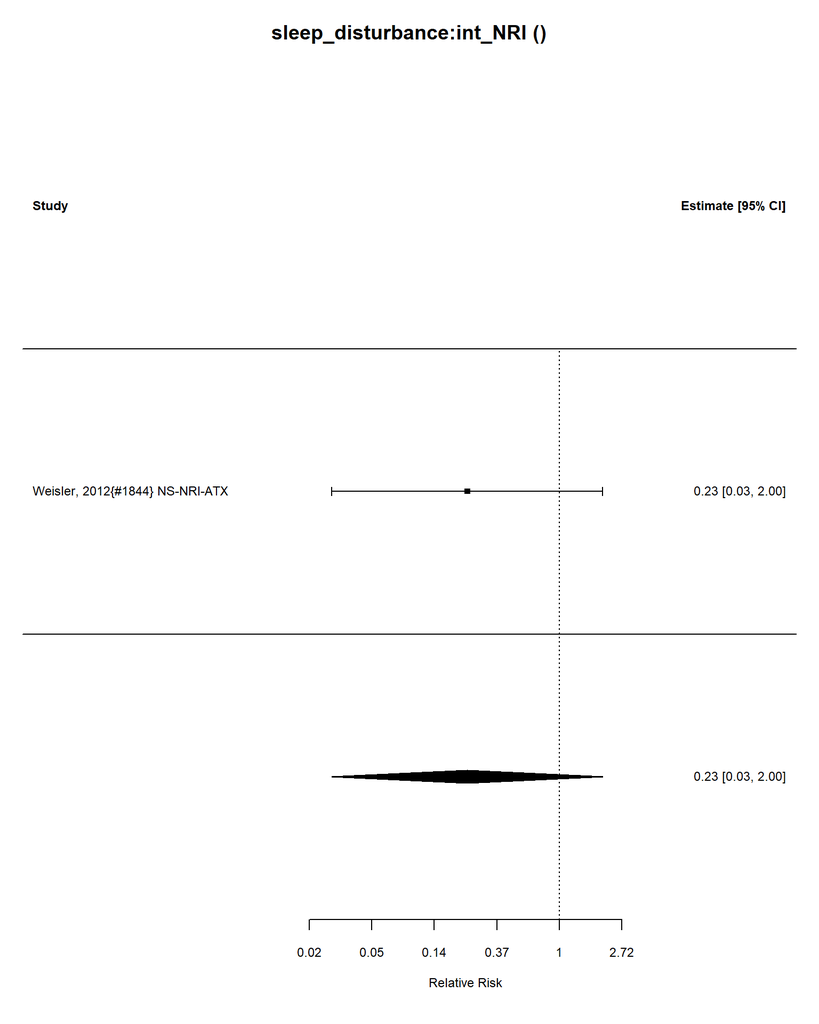

Number of studies = 1  
Intervention sample = 74  
Control sample = 73  
Total sample = 147

### Relative Risk Estimate

|  | estimate | se | zval | pval | ci.lb | ci.ub |
| --- | --- | --- | --- | --- | --- | --- |
| intrcpt | 0.2299255 | 3.034358 | 0.2644773 | 1.197217 | 0.0262523 | 2.013753 |

I-squared = 0 %

## Intervention: int_NRI

### Outcome: AEs:continuous

No data #1.

## Intervention: int_NRI

### Outcome: AEs:categorical

Analyzing 1 studies.

Analyzing 1 studies.

### Control Types

| control | n |
| --- | --- |
| Placebo | 1 |

| ID | measure | yi | se | study.design |
| --- | --- | --- | --- | --- |
| Weisler, 2012{#1844} NS-NRI-ATX | Number of participants reporting any adverse events | 0.02 | 0.08 | RCT |

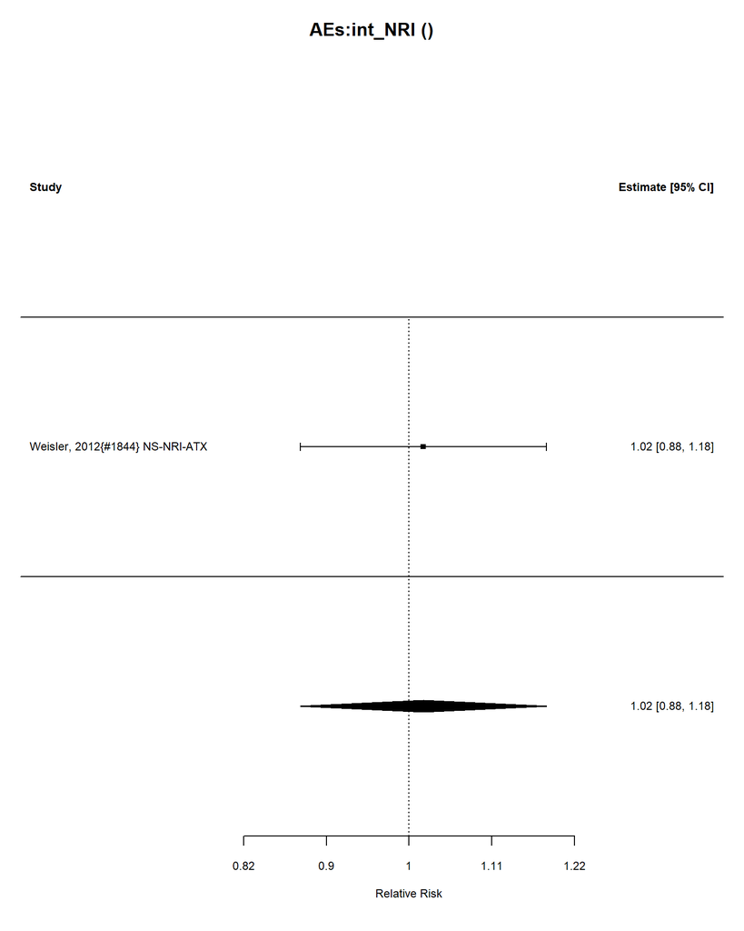

Number of studies = 1  
Intervention sample = 74  
Control sample = 73  
Total sample = 147

### Relative Risk Estimate

|  | estimate | se | zval | pval | ci.lb | ci.ub |
| --- | --- | --- | --- | --- | --- | --- |
| intrcpt | 1.020201 | 1.083287 | 1.2586 | 2.2705 | 0.8780954 | 1.185305 |

I-squared = 0 %

## Intervention: int_NRI

### Outcome: mortality:continuous

No data #1.

## Intervention: int_NRI

### Outcome: mortality:categorical

Analyzing 1 studies.

Analyzing 1 studies.

### Control Types

| control | n |
| --- | --- |
| Placebo | 1 |

| ID | measure | yi | se | study.design |
| --- | --- | --- | --- | --- |
| Weisler, 2012{#1844} NS-NRI-ATX | Number of deaths | 0.08 | 1.99 | RCT |

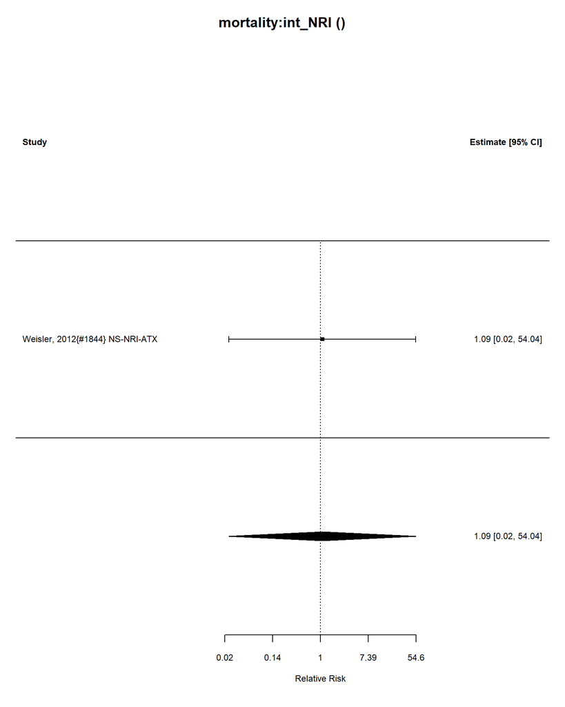

Number of studies = 1  
Intervention sample = 74  
Control sample = 73  
Total sample = 147

### Relative Risk Estimate

|  | estimate | se | zval | pval | ci.lb | ci.ub |
| --- | --- | --- | --- | --- | --- | --- |
| intrcpt | 1.083287 | 7.315534 | 1.040811 | 2.637945 | 0.0219278 | 54.05489 |

I-squared = 0 %

## Intervention: int_NRI

### Outcome: behavior:continuous

No data #1.

## Intervention: int_NRI

### Outcome: behavior:categorical

Analyzing 0 studies.

No data.

## Intervention: int_NRI

### Outcome: appetite:continuous

No data #1.

## Intervention: int_NRI

### Outcome: appetite:categorical

Analyzing 1 studies.

Analyzing 1 studies.

### Control Types

| control | n |
| --- | --- |
| Placebo | 1 |

| ID | measure | yi | se | study.design |
| --- | --- | --- | --- | --- |
| Weisler, 2012{#1844} NS-NRI-ATX | Decreased appetite adverse event | -0.8 | 0.42 | RCT |

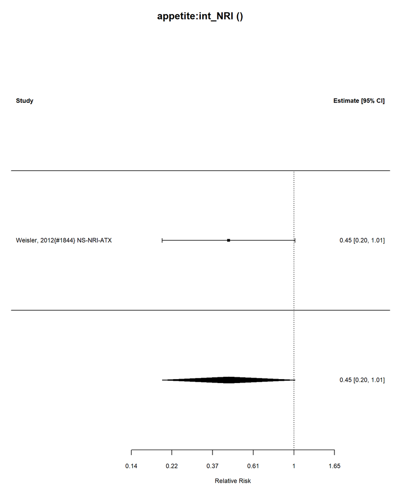

Number of studies = 1  
Intervention sample = 74  
Control sample = 73  
Total sample = 147

### Relative Risk Estimate

|  | estimate | se | zval | pval | ci.lb | ci.ub |
| --- | --- | --- | --- | --- | --- | --- |
| intrcpt | 0.449329 | 1.521962 | 0.1451482 | 1.051271 | 0.1978987 | 1.01005 |

I-squared = 0 %

## Intervention: int_NRI

### Outcome: mood:continuous

No data #1.

## Intervention: int_NRI

### Outcome: mood:categorical

Analyzing 1 studies.

Analyzing 1 studies.

### Control Types

| control | n |
| --- | --- |
| Placebo | 1 |

| ID | measure | yi | se | study.design |
| --- | --- | --- | --- | --- |
| Kay, 2009{#2637} NS-NRI-ATX | Irritability | 1.61 | 1.51 | Crossover |

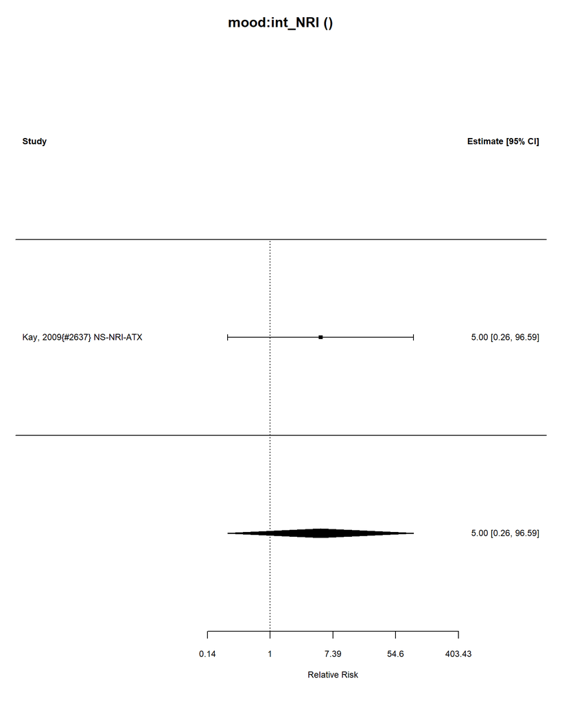

Number of studies = 1  
Intervention sample = 16  
Control sample = 16  
Total sample = 32

### Relative Risk Estimate

|  | estimate | se | zval | pval | ci.lb | ci.ub |
| --- | --- | --- | --- | --- | --- | --- |
| intrcpt | 5.002811 | 4.526731 | 2.915379 | 1.336428 | 0.2592403 | 96.54411 |

I-squared = 0 %

## MPH, AMPH, and NRI’s Section: Intervention: int_stimulant

## Intervention: int_stimulant

### Outcome: functional:continuous

No data #1.

## Intervention: int_stimulant

### Outcome: functional:categorical

Analyzing 0 studies.

No data.

## Intervention: int_stimulant

### Outcome: cognitive:continuous

No data #1.

## Intervention: int_stimulant

### Outcome: cognitive:categorical

Analyzing 0 studies.

No data.

## Intervention: int_stimulant

### Outcome: symptom:continuous

No data #1.

## Intervention: int_stimulant

### Outcome: symptom:categorical

Analyzing 0 studies.

No data.

## Intervention: int_stimulant

### Outcome: substance_use:continuous

No data #1.

## Intervention: int_stimulant

### Outcome: substance_use:categorical

Analyzing 0 studies.

No data.

## Intervention: int_stimulant

### Outcome: relationship:continuous

No data #1.

## Intervention: int_stimulant

### Outcome: relationship:categorical

Analyzing 0 studies.

No data.

## Intervention: int_stimulant

### Outcome: BP:continuous

No data #1.

## Intervention: int_stimulant

### Outcome: BP:categorical

Analyzing 0 studies.

No data.

## Intervention: int_stimulant

### Outcome: sleep_disturbance:continuous

No data #1.

## Intervention: int_stimulant

### Outcome: sleep_disturbance:categorical

Analyzing 0 studies.

No data.

## Intervention: int_stimulant

### Outcome: AEs:continuous

No data #1.

## Intervention: int_stimulant

### Outcome: AEs:categorical

Analyzing 0 studies.

No data.

## Intervention: int_stimulant

### Outcome: mortality:continuous

No data #1.

## Intervention: int_stimulant

### Outcome: mortality:categorical

Analyzing 0 studies.

No data.

## Intervention: int_stimulant

### Outcome: behavior:continuous

No data #1.

## Intervention: int_stimulant

### Outcome: behavior:categorical

Analyzing 0 studies.

No data.

## Intervention: int_stimulant

### Outcome: appetite:continuous

No data #1.

## Intervention: int_stimulant

### Outcome: appetite:categorical

Analyzing 0 studies.

No data.

## Intervention: int_stimulant

### Outcome: mood:continuous

No data #1.

## Intervention: int_stimulant

### Outcome: mood:categorical

Analyzing 0 studies.

No data.

## MPH, AMPH, and NRI’s Section: Intervention: longterm

## Intervention: longterm

### Outcome: functional:continuous

No data #1.

## Intervention: longterm

### Outcome: functional:categorical

Analyzing 0 studies.

No data.

## Intervention: longterm

### Outcome: cognitive:continuous

No data #1.

## Intervention: longterm

### Outcome: cognitive:categorical

Analyzing 0 studies.

No data.

## Intervention: longterm

### Outcome: symptom:continuous

No data #1.

## Intervention: longterm

### Outcome: symptom:categorical

Analyzing 0 studies.

No data.

## Intervention: longterm

### Outcome: substance_use:continuous

No data #1.

## Intervention: longterm

### Outcome: substance_use:categorical

Analyzing 0 studies.

No data.

## Intervention: longterm

### Outcome: relationship:continuous

No data #1.

## Intervention: longterm

### Outcome: relationship:categorical

Analyzing 0 studies.

No data.

## Intervention: longterm

### Outcome: BP:continuous

No data #1.

## Intervention: longterm

### Outcome: BP:categorical

Analyzing 0 studies.

No data.

## Intervention: longterm

### Outcome: sleep_disturbance:continuous

No data #1.

## Intervention: longterm

### Outcome: sleep_disturbance:categorical

Analyzing 0 studies.

No data.

## Intervention: longterm

### Outcome: AEs:continuous

No data #1.

## Intervention: longterm

### Outcome: AEs:categorical

Analyzing 0 studies.

No data.

## Intervention: longterm

### Outcome: mortality:continuous

No data #1.

## Intervention: longterm

### Outcome: mortality:categorical

Analyzing 0 studies.

No data.

## Intervention: longterm

### Outcome: behavior:continuous

No data #1.

## Intervention: longterm

### Outcome: behavior:categorical

Analyzing 0 studies.

No data.

## Intervention: longterm

### Outcome: appetite:continuous

No data #1.

## Intervention: longterm

### Outcome: appetite:categorical

Analyzing 0 studies.

No data.

## Intervention: longterm

### Outcome: mood:continuous

No data #1.

## Intervention: longterm

### Outcome: mood:categorical

Analyzing 0 studies.

No data.

```r
rm(d_short)
```